# Regresión Lineal

Mike

2024-02-07

# Regresión lineal

Vamos a modelar la tendencia y estacionalidad de una serie de tiempo, a través de una regresión lineal.

Comenzamos de la forma estandar.

atajo para el Chunk o bloque de codigo ctrl+alt+i

```r
rm(list = ls())

library(tidyverse)
library(forecast)
library(readxl)

setwd("C:/Users/Ivan Salas/Desktop/pronosticos/regresion")
```

Vamos analizar el ICCJ, este el Índice del Consumidor Jaliscience del IIEG. Este un número Índice que mide las posibilidades economicas de realizar gastos de consumo en el hogar.

Cargamos los datos

```r
consumismo <- read_excel("indice_iccj.xlsx")
```

Vamos a cambiar el nombre de los datos

```r
names(consumismo) <- c("fecha","iccj","ropa","vacaciones")
```

Vamos a declara la serie de tiempo

```r
iccj <- ts(consumismo$iccj, start = c(2020,6), frequency = 12)
```

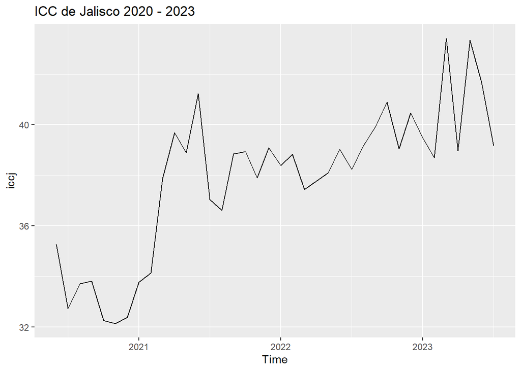

```r
autoplot(iccj)+
  ggtitle("ICC de Jalisco 2020 - 2023")
```

Vamos a modelar la tendencia y estacionalidad de la serie

$$iccj = \beta_0 +\beta_1 tendencia +
\beta_2 estacionalidad + u$$

Para estimar el modelo usamos la función *tslm*

```r
modelo1 <- tslm(iccj ~ trend + season)
```

```r
summary(modelo1)
```

```
##
## Call:
## tslm(formula = iccj ~ trend + season)
##
## Residuals:
##    Min     1Q Median     3Q    Max
## -2.656 -1.202  0.025  1.217  3.338
##
## Coefficients:
##             Estimate Std. Error t value Pr(>|t|)
## (Intercept)  33.1268     1.2013  27.577  < 2e-16 ***
## trend         0.2043     0.0280   7.294 1.21e-07 ***
## season2      -0.1966     1.5031  -0.131    0.897
## season3       1.9568     1.5039   1.301    0.205
## season4       0.9808     1.5052   0.652    0.521
## season5       2.0780     1.5071   1.379    0.180
## season6       2.2888     1.4061   1.628    0.116
## season7      -0.4261     1.4058  -0.303    0.764
## season8       0.3015     1.5094   0.200    0.843
## season9       1.1284     1.5071   0.749    0.461
## season10      0.7597     1.5052   0.505    0.618
## season11     -0.4471     1.5039  -0.297    0.769
## season12      0.2984     1.5031   0.199    0.844
## ---
## Signif. codes:  0 '***' 0.001 '**' 0.01 '*' 0.05 '.' 0.1 ' ' 1
##
## Residual standard error: 1.841 on 25 degrees of freedom
## Multiple R-squared:  0.7365, Adjusted R-squared:   0.61
## F-statistic: 5.822 on 12 and 25 DF,  p-value: 0.0001044
```

Como todos coef. asociados a la estacionalidad son iguales a cero, no existe estacionalidad.

Interpretar los coeficientes:

- Intercepto: El valor mínimo esperado es de 33.1268, es el valor constante del modelo, como el valor-p es practicamente cero, este coef. es estadísticamente significativo a los tres niveles de significancia, este coef. es (estadísticamente) diferente de cero.
- Tendencia: El valor del coeficiente es de 0.2043 y es significativo, por cada periodo el indice aumenta 0.2043 puntos
- season2 / Febrero: Durante Febrero, el indice disminuye 0.1966 puntos

Vamos a realizar el pronostico del siguiente mes:Agosto de 2023, para esto hacemos uso de los coeficientes estimados

```r
33.1268 + 0.2043*39 + 0.3015
```

```
## [1] 41.396
```

Para hacer el pronostico utilizamos la función forecast(), indicando el modelo a utilizar y con la opción *h*, el número de periodos a pronosticar:

```r
pronostico1 <- forecast(modelo1, h=12)

pronostico1
```

```
##          Point Forecast    Lo 80    Hi 80    Lo 95    Hi 95
## Aug 2023       41.39497 38.46067 44.32928 36.80399 45.98596
## Sep 2023       42.42613 39.49183 45.36044 37.83515 47.01712
## Oct 2023       42.26178 39.32748 45.19609 37.67080 46.85277
## Nov 2023       41.25916 38.32486 44.19347 36.66818 45.85015
## Dec 2023       42.20904 39.27474 45.14335 37.61806 46.80003
## Jan 2024       42.11486 39.18056 45.04917 37.52388 46.70585
## Feb 2024       42.12249 39.18818 45.05679 37.53150 46.71347
## Mar 2024       44.48018 41.54587 47.41449 39.88920 49.07116
## Apr 2024       43.70850 40.77419 46.64281 39.11752 48.29948
## May 2024       45.00994 42.07564 47.94425 40.41896 49.60093
## Jun 2024       45.42506 42.49910 48.35102 40.84714 50.00298
## Jul 2024       42.91436 39.98840 45.84032 38.33644 47.49228
```

Podemos graficar el pronostico:

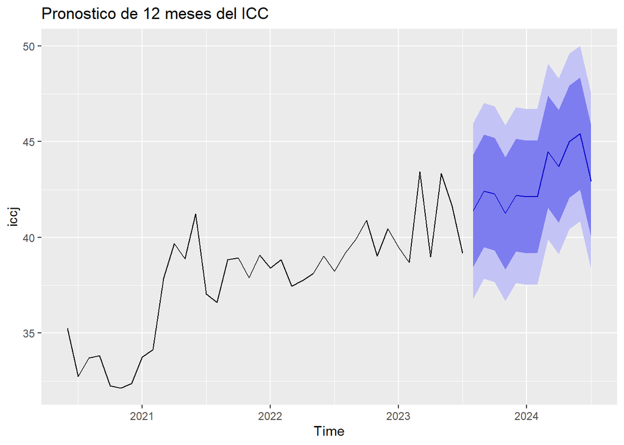

```r
autoplot(pronostico1)+
  ggtitle("Pronostico de 12 meses del ICC")
```

Podemos cambiar el nivel de confianza del pronostico

```r
pronostico1 <- forecast(modelo1, h=12, level = 0.93)
pronostico1
```

```
##          Point Forecast    Lo 93    Hi 93
## Aug 2023       41.39497 37.17539 45.61456
## Sep 2023       42.42613 38.20655 46.64572
## Oct 2023       42.26178 38.04220 46.48137
## Nov 2023       41.25916 37.03958 45.47875
## Dec 2023       42.20904 37.98946 46.42863
## Jan 2024       42.11486 37.89528 46.33445
## Feb 2024       42.12249 37.90290 46.34207
## Mar 2024       44.48018 40.26059 48.69977
## Apr 2024       43.70850 39.48891 47.92809
## May 2024       45.00994 40.79036 49.22953
## Jun 2024       45.42506 41.21748 49.63264
## Jul 2024       42.91436 38.70678 47.12194
```

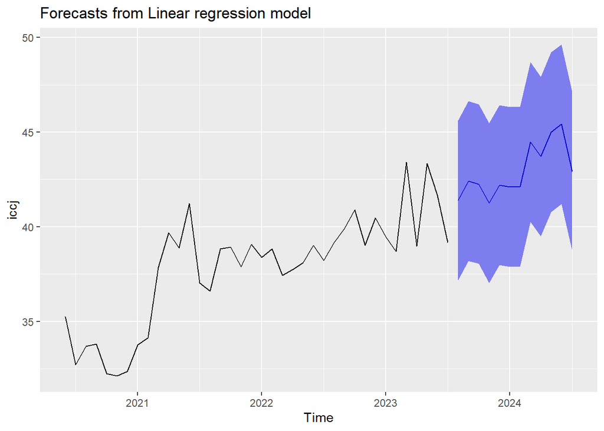

```r
autoplot(pronostico1)
```

# Índice de Ropa y vacaciones

Necesitamos manipular un poco la base de datos (filtrar) los valores perdidos.

En R, los valores perdidos se muestran como NA, debemos usar la función *filter* y el operador pipe (%>%) 7

El atajo del operador pipe es ctrl+shift+m

```r
consumismo2 <- consumismo %>%
  filter(ropa!="NA")
```

Generamos las dos series de tiempo

```r
ropa <- ts(consumismo2$ropa, start = c(2020,9), frequency = 12)

vacaciones <- ts(consumismo2$vacaciones, start = c(2020,9), frequency = 12)
```